# KWF_Beach_Sampling_Analysis_2019_2020

### Microbial Source Tracking

#### MST Data Table

```r
# recreate table in tab "2019-2020_FinalReport_MST2020"
mst_tbl <- mst_dat %>%
  arrange(location,date,analytical_method) %>%
  transform(date = as.Date(date)) %>%
  select(date,location,analytical_method,val) %>%
  pivot_wider(names_from = analytical_method, values_from = val) %>%
  arrange(date,location)

colnames(mst_tbl) <- c("Date","Location","Dog Feces","Gull Feces","Human Feces")

# print
datatable(mst_tbl,
          filter = 'top',
          options = list(pageLength = 5, autoWidth = TRUE))
```

|  | Date | Location | Dog Feces | Gull Feces | Human Feces |
| --- | --- | --- | --- | --- | --- |
| 1 | 2019-06-04 | Kenai River Gull Rookery 1 | ND | 3610 | DNQ |
| 2 | 2019-06-04 | Kenai River Gull Rookery 2 | ND | 2140 | ND |
| 3 | 2019-06-04 | North Kenai Beach 4 | 4660 | 965 | ND |
| 4 | 2019-06-04 | South Kenai Beach 3 | 1210 | 1380 | ND |
| 5 | 2019-06-04 | Warren Ames Bridge | ND | 1680 | DNQ |
| 6 | 2019-08-08 | Kenai River Gull Rookery 1 | ND | 3040 | 525 |
| 7 | 2019-08-08 | Kenai River Gull Rookery 2 | DNQ | 9010 | DNQ |
| 8 | 2019-08-08 | North Kenai Beach 4 | ND | 11600 | DNQ |
| 9 | 2019-08-08 | South Kenai Beach 3 | ND | 28200 | DNQ |
| 10 | 2019-08-08 | Warren Ames Bridge | DNQ | 2920 | DNQ |

[output cut: 10 more lines]

```r
# save mst data table
write.csv(mst_tbl, "output/mst_summary_table.csv", row.names = F)
```

What is the range of concentration values for each species?

```r
mst_dat %>%
  mutate(val = str_replace_all(val,c("ND" = "0",
                                     "DNQ" = "0"))) %>%
  transform(val = as.numeric(val)) %>%
  group_by(analytical_method) %>%
  summarise(min = min(val),
            max = max(val),
            mean = mean(val))
```

```
## # A tibble: 3 x 4
##   analytical_method   min   max  mean
## * <chr>             <dbl> <dbl> <dbl>
## 1 Dog_BacCan-UCD        0  4660  294.
## 2 Gull_Gull-4           0 28200 5418.
## 3 Human_HF183           0  1220  176.
```

#### MST Results Figure

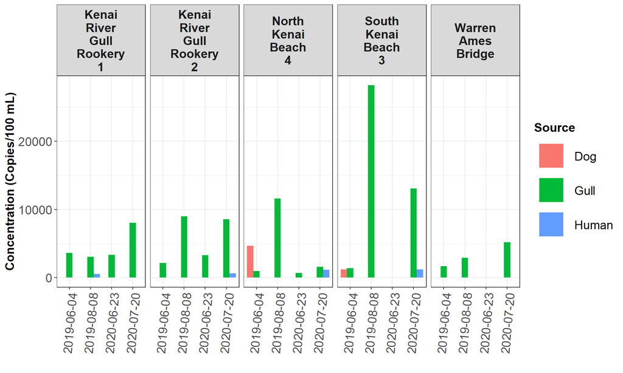

```r
# prep table for plot
mst_tbl <- mst_dat %>%
  filter(data_type == "Microbial Source Tracking") %>%
  arrange(location,date,analytical_method) %>%
  select(date,location,analytical_method,val) %>%
  # replace results DNQ and ND with zero and convert to numeric
  mutate(val = as.numeric(str_replace_all(val,c("DNQ" = "0", "ND" = "0"))))

# prep custom legend format functions from stack overflow: https://stackoverflow.com/questions/11366964/is-there-a-way-to-change-the-spacing-between-legend-items-in-ggplot2


draw_key_polygon3 <- function(data, params, size) {
  lwd <- min(data$size, min(size) / 4)

  grid::rectGrob(
    width = grid::unit(0.7, "npc"),
    height = grid::unit(0.7, "npc"),
    gp = grid::gpar(
      col = data$colour,
      fill = alpha(data$fill, data$alpha),
      lty = data$linetype,
      lwd = lwd * .pt,
      linejoin = "mitre"
    ))
}
GeomBar$draw_key = draw_key_polygon3


# plot
mst_tbl %>%
  ggplot(aes(as.factor(date),val, fill = analytical_method)) +
  geom_col(position = "dodge", key_glyph = "polygon3") +
  facet_grid(.~location, labeller = labeller(location = label_wrap_gen(5))) +
  xlab("") +
  ylab("Concentration (Copies/100 mL)") +
  theme_bw() +
   # modify legend
  scale_fill_discrete(name="Source",
                         breaks=c("Dog_BacCan-UCD", "Gull_Gull-4", "Human_HF183"),
                         labels=c("Dog", "Gull", "Human")) +
  # theme
  theme(axis.text.x = element_text(vjust = .5, angle = 85),
        strip.text.y = element_text(angle = 0),
        legend.key.size = unit(1.4,"cm")) +
  col_theme
```

```r
# save plot
ggsave("output/mst_kenai_beach_2019_2020.png", width = 12, height = 6)
```

### Enterococci and Fecal Coliform Concentrations

#### Bacteria Concentrations Data Table

```r
# prep table
bac_tbl <- dat %>%
  filter(data_type %in% c("Enterococci","Fecal Coliform")) %>%
  arrange(location,date,data_type) %>%
  select(date,location,data_type,val) %>%

  # replace results DNQ and ND with zero and convert to numeric
  mutate(val = as.numeric(str_replace_all(val,c("DNQ" = "0", "ND" = "0")))) %>%

   # use day of year for x axis and year for facet grid
  mutate(day = yday(date),
         year = year(date))

# print
datatable(bac_tbl,
          filter = 'top',
          options = list(pageLength = 5, autoWidth = TRUE))
```

|  | date | location | data_type | val | day | year |
| --- | --- | --- | --- | --- | --- | --- |
| 1 | 2019-05-21T00:00:00Z | Kenai River Gull Rookery 1 | Fecal Coliform | 5 | 141 | 2019 |
| 2 | 2019-05-29T00:00:00Z | Kenai River Gull Rookery 1 | Fecal Coliform | 5 | 149 | 2019 |
| 3 | 2019-06-04T00:00:00Z | Kenai River Gull Rookery 1 | Enterococci | 6 | 155 | 2019 |
| 4 | 2019-06-04T00:00:00Z | Kenai River Gull Rookery 1 | Fecal Coliform | 8 | 155 | 2019 |
| 5 | 2019-06-11T00:00:00Z | Kenai River Gull Rookery 1 | Enterococci | 20 | 162 | 2019 |
| 6 | 2019-06-11T00:00:00Z | Kenai River Gull Rookery 1 | Fecal Coliform | 46 | 162 | 2019 |
| 7 | 2019-06-18T00:00:00Z | Kenai River Gull Rookery 1 | Enterococci | 23 | 169 | 2019 |
| 8 | 2019-06-18T00:00:00Z | Kenai River Gull Rookery 1 | Fecal Coliform | 25 | 169 | 2019 |
| 9 | 2019-06-25T00:00:00Z | Kenai River Gull Rookery 1 | Fecal Coliform | 7 | 176 | 2019 |
| 10 | 2019-07-02T00:00:00Z | Kenai River Gull Rookery 1 | Enterococci | 34 | 183 | 2019 |

[output cut: 256 more lines]

#### Bacteria Concentrations Figures

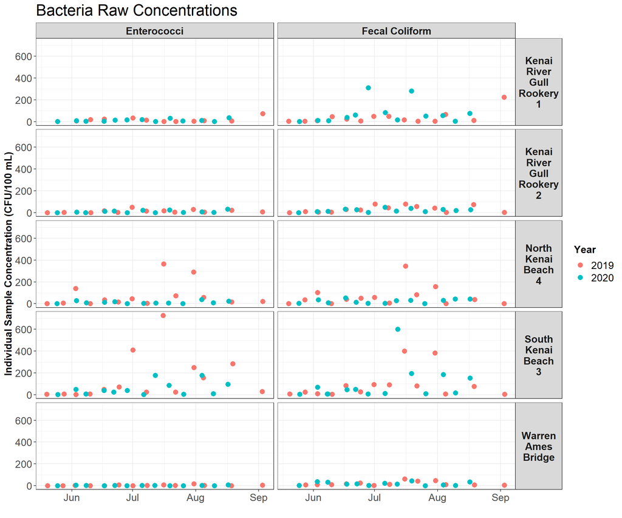

```r
# plot 1
bac_tbl %>%
  ggplot(aes(x = as.Date(paste(2014,strftime(date,format="%m-%d"),sep="-")),
                           y = val,
                           color = as.factor(year))) +
  geom_jitter(size = 3) +
  facet_grid(location~data_type, labeller = labeller(location = label_wrap_gen(5))) +
  xlab("") +
  ylab("Individual Sample Concentration (CFU/100 mL)") +
  scale_color_discrete(name = "Year")+
  # theme
  theme_bw() +
  theme(axis.text.x = element_text(vjust = 1),
        strip.text.y = element_text(angle = 0)) +
  points_theme +
  ggtitle("Bacteria Raw Concentrations")
```

```r
# save plot
ggsave("output/bacteria_conc_2019_2020_v1.png", width = 10, height = 10)
```

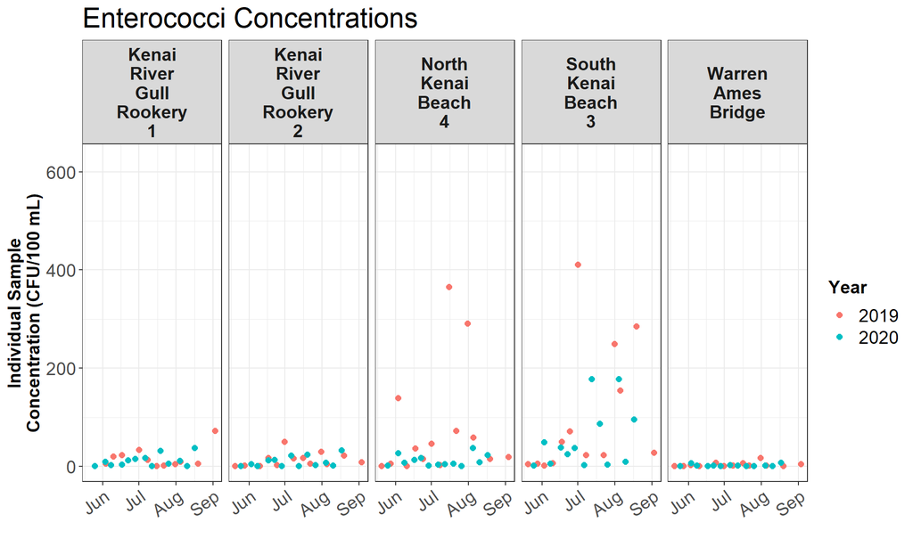

```r
# plot 2, enterococci
bac_tbl %>%
  filter(data_type == "Enterococci") %>%
  # note; use of year for date format is "fake" placeholder
  ggplot(aes(x = as.Date(paste(2014,strftime(date,format="%m-%d"),sep="-")),
                           y = val,
                           color = as.factor(year))) +
  geom_jitter(size = 2) +
  facet_grid(. ~ location, scales = "free_y", labeller = labeller(location = label_wrap_gen(5))) +
  xlab("") +
  ylab("Individual Sample\nConcentration (CFU/100 mL)") +
  ylim(0,625) +
  scale_color_discrete(name = "Year") +

  # single-sample threshold
 # geom_hline(aes(yintercept = 130, linetype =  "Raw seafood consumption\n(130 CFU/100 mL)"), color = "blue") +
  scale_linetype_manual(name = "Threshold", values = c(2, 2),
                        guide = guide_legend(override.aes = list(color = c("blue")))) +
  # overall theme
  theme_bw() +
  theme(axis.text.x = element_text(vjust = 1,hjust = 1, angle = 35),
        strip.text.y = element_text(angle = 0)) +
  ggtitle("Enterococci Concentrations") +
  points_theme
```

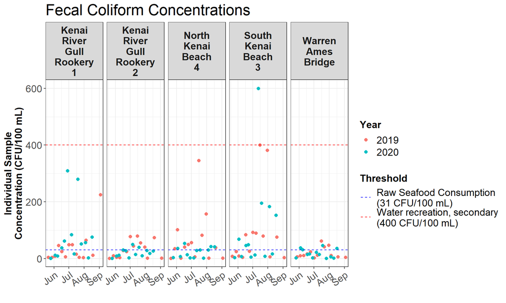

```r
# save plot
ggsave("output/enterococci_conc_2019_2020.png", width = 10, height = 4)


# plot 3, fecal coliform
bac_tbl %>%
  filter(data_type == "Fecal Coliform") %>%
  # note; use of year for date format is "fake" placeholder
  ggplot(aes(x = as.Date(paste(2014,strftime(date,format="%m-%d"),sep="-")),
                           y = val,
                           color = as.factor(year))) +
  geom_jitter(size = 2) +
  facet_grid(. ~ location, scales = "free_y", labeller = labeller(location = label_wrap_gen(5))) +
  xlab("") +
  ylab("Individual Sample\nConcentration (CFU/100 mL)") +
  scale_color_discrete(name = "Year") +

  # single-sample thresholds
  geom_hline(aes(yintercept = 31, linetype =  "Raw Seafood Consumption\n(31 CFU/100 mL)"), color = "blue") +
  geom_hline(aes(yintercept = 400, linetype =  "Water recreation, secondary\n(400 CFU/100 mL)"), color = "red") +
  scale_linetype_manual(name = "Threshold", values = c(2, 2),
                        guide = guide_legend(override.aes = list(color = c("blue","red")))) +
  # overall theme
  theme_bw() +
  theme(axis.text.x = element_text(vjust = 1,hjust = 1, angle = 35),
        strip.text.y = element_text(angle = 0)) +
  points_theme +
  ggtitle("Fecal Coliform Concentrations")
```

```r
# save plot
ggsave("output/fecal_coliform_conc_2019_2020.png", width = 10, height = 4)
```

### Exeedence Frequency Definitions

Define ADEC threshold values

Results were evaluated as follows:

*Fecal coliform*

Fecal coliform exceedances were determined based on standards set for:

1. Secondary water recreation

   a.) In-season exceedances for secondary contact recreation were identified when

   i.) Individual fecal coliform sample values exceeded 400 CFU/100 mL, or

   ii.) The geometric mean of fecal coliform samples exceeded 200 CFU/100 mL over a 30 day period.

   b.) Post-season site exceedances were identified post-season if 10% of fecal coliform sample values exceeded 400 CFU/100 mL.
2. Harvesting raw aquatic life for consumption

   a.) In-season exceedances for harvesting raw aquatic life for consumption were identified when

   i.) Individual fecal coliform samples exceeded 31 CFU/100 mL

   b.) Post-season site exceedances were identified when

   i.) 10% of fecal coliform samples from season exceeded 31 CFU/100 mL, or

   ii.) The geometric mean of fecal coliform samples from the season exceeded 14 CFU/100 mL.

*Enterococci*

Enterococci exceedances were determined based on standards set for:

1. Contact recreation

   a.) In-season exceedances for contact recreation were identified when

   i.) Individual enterococci samples exceeded 130 CFU/100 mL, or

   ii.) The geometric mean of enterococci samples exceeded 35 CFU/100 mL over a 30 day period.

   b.) Post-season site exceedances were identified when 10% of enterococci samples from the season exceeded 130 CFU/ 100 mL

Other notes:

- When a contact or secondary recreation exceedance occurred during the recreational season, a public advisory was issued by ADEC. Advisories were active until two consecutive weeks of bacteria concentrations below exceedance criteria were achieved. When an exceedance for harvesting raw aquatic life for consumption occurred, the ADEC seafood monitoring group was notified with an online notice.

General Data Notes

- For geometric mean calculations, non-detect values were assigned 50% their method detection limit: See section 2.4.1 of ADEC “Listing Methodology for Determining Water Quality Impairments from Pathogens”: “It is appropriate to consider non-detect samples when calculating the geometric mean for assessment purposes. Rather than eliminating the”non-detects" from the assessment data, these results and sample results measured below the detection limit will be calculated as 50% of the method detection limit. This approach may not be appropriate during the analysis of water quality trends."

### Exeedence Frequency Analysis

Calculate 30-day rolling geometric mean values for Enterococci and Fecal Coliform concentrations

```r
dat  <- dat %>%
  filter(data_type %in% c("Fecal Coliform","Enterococci")) %>%
  mutate(year = year(date)) %>%
  transform(val = as.numeric(val)) %>%

  # use 50% of value if it has an "Undetected" qualifier
  mutate(val = ifelse(is.na(qualifier),val,
                      ifelse(qualifier == "U",(val*.5),val))) %>%
  group_by(data_type,location,year) %>%
  arrange(year,data_type,location,date) %>%

  # calculate 30 day rolling geometric means
  mutate(gm30 = rollapplyr(val, 1:n() - findInterval(date - days(30), date),
                           geometric.mean, fill = NA, partial = T)) %>%

  # mutate values from the first annual 30 days of sampling to NA. (We need 30 days for a 30-day rolling geometric mean value).
  mutate(gm30 = as.numeric(ifelse(date < min(date + days(30)),"",gm30)))
```

Assign exceedance criteria for 30-day geometric means and individual sample values

```r
# create columns of Exceedance occurrences; individual and 30-day geometric means

# reshape dataframe
dat <- dat %>%
  rename("value" = "val") %>%

  # apply inseason criteria

  ## individual sample exceedances
  mutate(indv_excd = case_when(
    (value < 31 & data_type == "Fecal Coliform") ~ "no_indv_excd",
    (value >= 400 & data_type == "Fecal Coliform") ~ "fc_excd_400",
    (value >= 31 & value < 400 & data_type == "Fecal Coliform") ~ "fc_excd_31")) %>%

  ## 30 day rolling geometric mean exceedances
  mutate(gm30_excd = case_when(
    (gm30 < 200 & data_type == "Fecal Coliform") ~ "no_gm_excd",
    (gm30 >= 200 & data_type == "Fecal Coliform") ~ "gm_fc_excd_200")) %>%

  # enterococci

  ## individual sample Exceedances
  mutate(indv_excd = case_when(
    (indv_excd != "NA") ~ indv_excd,
    (value < 130 & data_type == "Enterococci") ~ "no_indv_excd",
    (value >= 130 & data_type == "Enterococci") ~ "ec_excd_130")) %>%

  ## 30 day rolling geometric mean exceedances
  mutate(gm30_excd = case_when(
    (gm30_excd != "NA") ~ gm30_excd,
    (gm30 < 35 & data_type == "Enterococci") ~ "no_gm_excd",
    (gm30 >= 35 & data_type == "Enterococci") ~ "gm_ec_excd_35"))
```

Export data table for annual report appendix

```r
# prep table for export
excd_tbl <- dat %>%
  # select columns
  select(location,data_type,date,value,gm30,indv_excd,gm30_excd) %>%
  transform(gm30 = format(round(as.numeric(gm30),1))) %>%
  mutate(gm30_excd = case_when(
    (gm30_excd == "gm_fc_excd_200") ~ "> 200",
    (gm30_excd == "gm_ec_excd_35") ~ "> 35")) %>%
  mutate(indv_excd = case_when(
    (indv_excd == "fc_excd_31") ~ "> 31",
    (indv_excd == "ec_excd_130") ~ "> 130",
    (indv_excd == "fc_excd_400") ~ "> 400")) %>%
   # replace NAs with blank spaces
  mutate_at(vars(gm30_excd,indv_excd), ~replace_na(., "")) %>%
  rename(Location = location,
         Year = year,
         Bacteria = data_type,
         Date = date,
         `30 Day Rolling Geometric Mean Value` = gm30,
         `Individual Sample Value` = value,
         `30 Day Geometric Mean Exceedance` = gm30_excd,
         `Individual Sample Value Exceedance` = indv_excd)

# save table
write.csv(excd_tbl,"output/exceedance_table.csv", row.names = F)

## manually format conditional color and page sizes in excel
```

#### Fecal Coliform

1. Secondary Water Recreation
   1. In-season exceedances
      - When do individual fecal concentration values > 31 CFU/100 mL?
      - When do individual fecal concentration values > 400 CFU/100 mL?

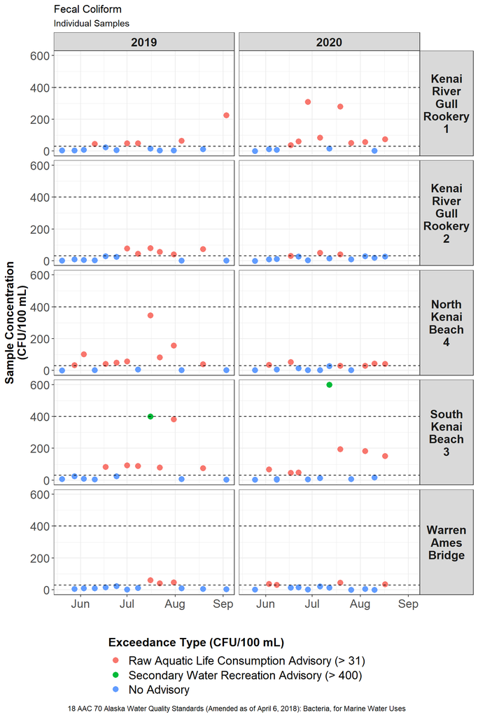

```r
# render plot
bact <- "Fecal Coliform"
dat %>%
  filter(data_type == bact) %>%
  ggplot(aes(as.Date(paste(2014,strftime(date,format="%m-%d"),sep="-")),
             value,
             color = indv_excd)) +
    geom_point(size = 3) +

  # indv. sample std for harvesting raw aquatic life = 31 CFU/100 mL
  geom_hline(yintercept = 31, lty = "dashed") +

  # indv. sample std for secondary water recreation = 400 CFU/100 mL
  geom_hline(yintercept = 400, lty = "dashed") +

    facet_grid(location ~ year, labeller = labeller(location = label_wrap_gen(5))) +
  xlab("") +
  ylab("Sample Concentration\n(CFU/100 mL)") +
  theme_bw() +
  theme(strip.text.y = element_text(angle = 0),
        legend.direction = "vertical",
        legend.position = "bottom") +

  scale_color_discrete(name="Exceedance Type (CFU/100 mL)",
                      breaks = c("fc_excd_31",
                                 "fc_excd_400",
                                 "no_indv_excd"),
                      labels = c("Raw Aquatic Life Consumption Advisory (> 31)",
                                 "Secondary Water Recreation Advisory (> 400)",
                                 "No Advisory")) +
  col_theme +

  # top title
  ggtitle("Fecal Coliform") +

  # top and bottom subtitles
  labs(subtitle = "Individual Samples",
       caption = "18 AAC 70 Alaska Water Quality Standards (Amended as of April 6, 2018): Bacteria, for Marine Water Uses") +
  theme(plot.caption = element_text(hjust=0.5, size=rel(0.8)))
```

```r
# save
ggsave("output/fc_indv.png", width = 16, height = 22, units = "cm")
```

- When do 30 day geometric mean fecal coliform values exceed 200 CFU/100 mL?

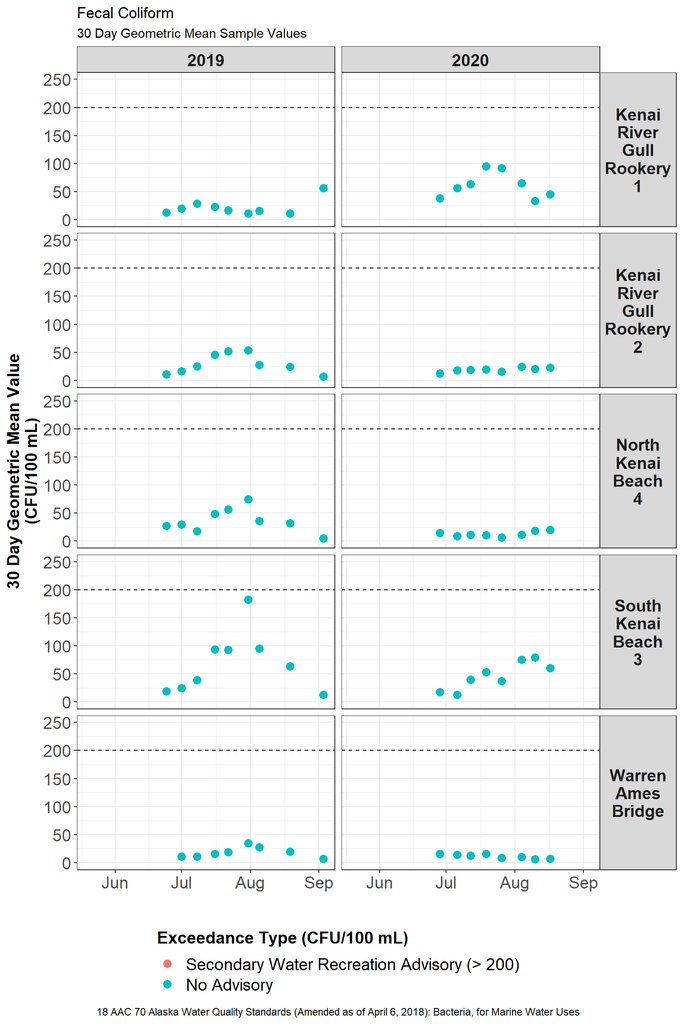

```r
# prep for legend
## values of >200 rare for geometric mean.  add dummy row so that it still shows up in legend
dat <- dat %>%
  ungroup() %>%
  add_row(gm30_excd = "gm_fc_excd_200", gm30 = 0)


# render plot
bact <- "Fecal Coliform"
dat %>%
  filter(data_type == bact) %>%
  ggplot(aes(as.Date(paste(2014,strftime(date,format="%m-%d"),sep="-")),
             gm30,
             color = gm30_excd)) +
    geom_point(size = 3) +

  # indv. sample std for harvesting raw aquatic life = 31 CFU/100 mL
  geom_hline(yintercept = 200, lty = "dashed") +

  facet_grid(location ~ year, labeller = labeller(location = label_wrap_gen(5))) +
  ylim(0,250) +
  xlab("") +
  ylab("30 Day Geometric Mean Value\n(CFU/100 mL)") +
  theme_bw() +
  theme(strip.text.y = element_text(angle = 0),
        legend.direction = "vertical",
        legend.position = "bottom") +

  scale_color_discrete(name="Exceedance Type (CFU/100 mL)",
                      breaks = c("fc_excd_200",
                                 "no_gm_excd"),
                      labels = c("Secondary Water Recreation Advisory (> 200)",
                                 "No Advisory"),
                      # force legend to show all values even if no exceedances present
                      limits = c("fc_excd_200", "no_gm_excd")) +
  col_theme +

  # top title
  ggtitle("Fecal Coliform") +

  # top and bottom subtitles
  labs(subtitle = "30 Day Geometric Mean Sample Values",
       caption = "18 AAC 70 Alaska Water Quality Standards (Amended as of April 6, 2018): Bacteria, for Marine Water Uses") +
  theme(plot.caption = element_text(hjust=0.5, size=rel(0.8)))
```

```r
# save
ggsave("output/fc_geomean.png", width = 16, height = 22, units = "cm")
```

2.) Post-season exceedances

```r
library(extdplyr)

# render table
bact <- "Fecal Coliform"
z <- dat %>%
  filter(data_type == bact) %>%

  # calculate percentages by exceedance type
  pct_routine(location,year,indv_excd,
              ungroup = T) %>%
  transform(year = as.factor(year)) %>%

  # assign pass/fail
  filter(indv_excd != "no_indv_excd") %>%
  separate(indv_excd, sep = "_",into = c("a","b","std")) %>%
  mutate(pass_fail = ifelse(pct > .1, "fail","pass")) %>%
  select(-a,-b) %>%
      adorn_pct_formatting() %>%
  rename("Location" = "location",
         "Year" = "year",
         "% of Sample Above Standard" = "pct",
         "Standard (CFU/100 mL)" = "std",
         "Pass/Fail" = "pass_fail") %>%
  arrange(Location,Year)

# save table
write.csv(z, "output/fc_site_exd_pct.csv", row.names = F)
```

- At which sites does the geometric mean of all samples from a season exceed 14 CFU/100 mL?

```r
# render table
bact <- "Fecal Coliform"
(z <- dat %>%
  filter(data_type == bact) %>%

  # calculate seasonal geometric means
  group_by(location,year) %>%
  summarise(seasonal_gm30 = mean(gm30, na.rm =T),
            n = n()) %>%

  # assign pass/fail
  mutate(pass_fail = ifelse(seasonal_gm30 > 14,"fail","pass")) %>%
  rename("Location" = "location",
         "Year" = "year",
         "Seasonal Average of 30 Day Geometric Mean Fecal Coliform" = "seasonal_gm30",
         "Pass/Fail" = "pass_fail"))
```

```
## # A tibble: 10 x 5
## # Groups:   Location [5]
##    Location           Year `Seasonal Average of 30 Day Geomet~     n `Pass/Fail`
##    <chr>             <dbl>                               <dbl> <int> <chr>
##  1 Kenai River Gull~  2019                                21.6    14 fail
##  2 Kenai River Gull~  2020                                61.1    13 fail
##  3 Kenai River Gull~  2019                                29.2    14 fail
##  4 Kenai River Gull~  2020                                18.9    13 fail
##  5 North Kenai Beac~  2019                                36.5    14 fail
##  6 North Kenai Beac~  2020                                12.8    13 pass
##  7 South Kenai Beac~  2019                                69.2    14 fail
##  8 South Kenai Beac~  2020                                47.0    14 fail
##  9 Warren Ames Brid~  2019                                18.2    13 fail
## 10 Warren Ames Brid~  2020                                11.2    13 pass
```

```r
# save
write.csv(z, "output/fc_season_geomean.csv", row.names = F)
```

#### Enterococci

1.) Contact recreation; in-season exceedances

- When did individual enterococci samples exceed 130 CFU/100 mL?

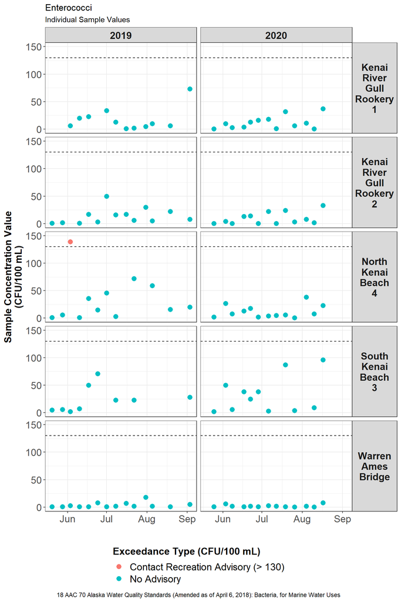

```r
# render plot
bact <- "Enterococci"
dat %>%
  filter(data_type == bact) %>%
  ggplot(aes(as.Date(paste(2014,strftime(date,format="%m-%d"),sep="-")),
             value,
             color = indv_excd)) +
    geom_point(size = 3) +

  # indv. sample std for harvesting raw aquatic life = 130 CFU/100 mL
  geom_hline(yintercept = 130, lty = "dashed") +

  facet_grid(location ~ year, labeller = labeller(location = label_wrap_gen(5))) +
  ylim(0,150) +
  xlab("") +
  ylab("Sample Concentration Value\n(CFU/100 mL)") +
  theme_bw() +
  theme(strip.text.y = element_text(angle = 0),
        legend.direction = "vertical",
        legend.position = "bottom") +

  scale_color_discrete(name="Exceedance Type (CFU/100 mL)",
                      breaks = c("ec_excd_130",
                                 "no_indv_excd"),
                      labels = c("Contact Recreation Advisory (> 130)",
                                 "No Advisory"),
                      # force legend to show all values even if no exceedances present
                      limits = c("ec_excd_130", "no_indv_excd")) +
  col_theme +

  # top title
  ggtitle("Enterococci") +

  # top and bottom subtitles
  labs(subtitle = "Individual Sample Values",
       caption = "18 AAC 70 Alaska Water Quality Standards (Amended as of April 6, 2018): Bacteria, for Marine Water Uses") +
  theme(plot.caption = element_text(hjust=0.5, size=rel(0.8)))
```

```r
# save
ggsave("output/ec_indv.png", width = 16, height = 22, units = "cm")
```

- When did the 30-day geometric mean sample values exceed 35 CFU/100 mL?

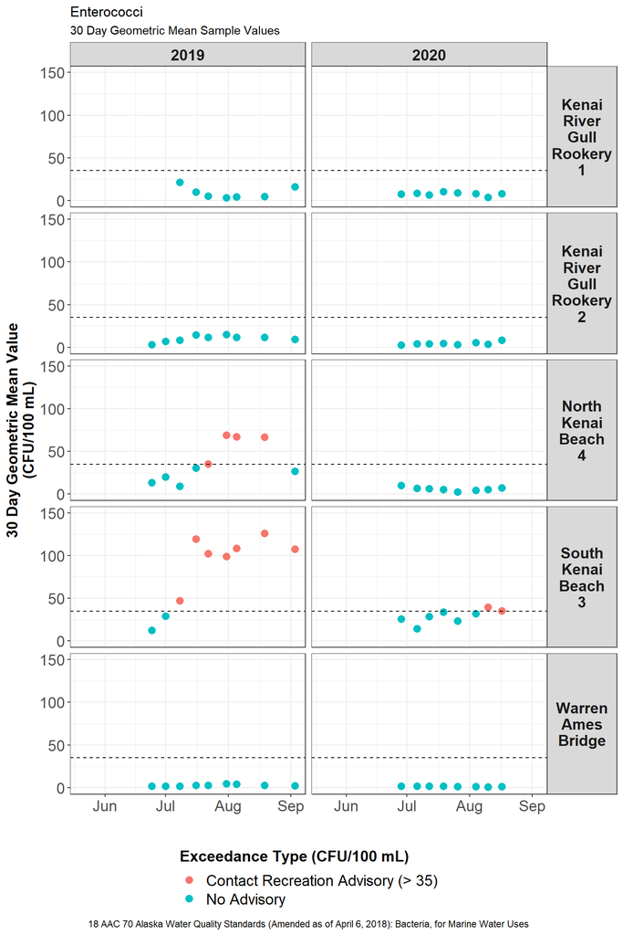

```r
# render plot
bact <- "Enterococci"
dat %>%
  filter(data_type == bact) %>%
  ggplot(aes(as.Date(paste(2014,strftime(date,format="%m-%d"),sep="-")),
             gm30,
             color = gm30_excd)) +
    geom_point(size = 3) +

  # 30 day geomean standard for contact recreation = 35 CFU/100 mL
  geom_hline(yintercept = 35, lty = "dashed") +

  facet_grid(location ~ year, labeller = labeller(location = label_wrap_gen(5))) +
  ylim(0,150) +
  xlab("") +
  ylab("30 Day Geometric Mean Value\n(CFU/100 mL)") +
  theme_bw() +
  theme(strip.text.y = element_text(angle = 0),
        legend.direction = "vertical",
        legend.position = "bottom") +

  scale_color_discrete(name="Exceedance Type (CFU/100 mL)",
                      breaks = c("gm_ec_excd_35",
                                 "no_gm_excd"),
                      labels = c("Contact Recreation Advisory (> 35)",
                                 "No Advisory"),
                      # force legend to show all possible values even if no exceedances present
                      limits = c("gm_ec_excd_35", "no_gm_excd")) +
  col_theme +

  # top title
  ggtitle(bact) +

  # top and bottom subtitles
  labs(subtitle = "30 Day Geometric Mean Sample Values",
       caption = "18 AAC 70 Alaska Water Quality Standards (Amended as of April 6, 2018): Bacteria, for Marine Water Uses") +
  theme(plot.caption = element_text(hjust=0.5, size=rel(0.8)))
```

```r
# save
ggsave("output/ec_geomean.png", width = 16, height = 22, units = "cm")
```

2.) Contact recreation, post-season exceedance

- What percentage of enterococci samples from the whole season exceeded 130 CFU/100 mL?

```r
# render table
bact <- "Enterococci"
(z <- dat %>%
  filter(data_type == bact) %>%

  # calculate percentages by exceedance type
  pct_routine(location,year,indv_excd,
              ungroup = T) %>%
  transform(year = as.factor(year)) %>%

  # assign pass/fail
  filter(indv_excd != "no_indv_excd") %>%
  separate(indv_excd, sep = "_",into = c("a","b","std")) %>%
  mutate(pass_fail = ifelse(pct > .1, "fail","pass")) %>%
  select(-a,-b) %>%
      adorn_pct_formatting() %>%
  rename("Location" = "location",
         "Year" = "year",
         "% of Sample Above Standard" = "pct",
         "Standard (CFU/100 mL)" = "std",
         "Pass/Fail" = "pass_fail") %>%
  arrange(Location,Year) )
```

```
##              Location Year Standard (CFU/100 mL) % of Sample Above Standard
## 1 North Kenai Beach 4 2019                   130                      21.4%
## 2 South Kenai Beach 3 2019                   130                      35.7%
## 3 South Kenai Beach 3 2020                   130                      15.4%
##   Pass/Fail
## 1      fail
## 2      fail
## 3      fail
```

```r
# save table
write.csv(z, "output/ec_site_exd_pct.csv", row.names = F)
```

–future goal: use “heat map calendar” format: https://vietle.info/post/calendarheatmap/

#### Overall Summaries

What was the range of geometric mean values?

```r
# by year
(summ_tbl <- dat %>%
  group_by(location,data_type,year) %>%
  filter(!is.na(gm30)) %>%
  summarise(gm30_mean = mean(gm30),
            gm30_se = std.error(gm30),
            gm30_max = max(gm30),
            gm30_min = min(gm30)))
```

```
## # A tibble: 21 x 7
## # Groups:   location, data_type [11]
##    location               data_type     year gm30_mean gm30_se gm30_max gm30_min
##    <chr>                  <chr>        <dbl>     <dbl>   <dbl>    <dbl>    <dbl>
##  1 Kenai River Gull Rook~ Enterococci   2019      9.37   2.62     21.2      3.38
##  2 Kenai River Gull Rook~ Enterococci   2020      7.84   0.654    10.4      4.02
##  3 Kenai River Gull Rook~ Fecal Colif~  2019     21.6    4.73     56.0     10.9
##  4 Kenai River Gull Rook~ Fecal Colif~  2020     61.1    8.08     94.9     33.5
##  5 Kenai River Gull Rook~ Enterococci   2019     10.4    1.26     14.9      3.18
##  6 Kenai River Gull Rook~ Enterococci   2020      4.52   0.615     8.24     2.83
##  7 Kenai River Gull Rook~ Fecal Colif~  2019     29.2    5.86     53.6      6.66
##  8 Kenai River Gull Rook~ Fecal Colif~  2020     18.9    1.32     24.4     12.6
##  9 North Kenai Beach 4    Enterococci   2019     37.6    7.96     69.2      9.43
## 10 North Kenai Beach 4    Enterococci   2020      6.05   0.764    10.0      2.61
## # ... with 11 more rows
```

```r
# save
write.csv(summ_tbl, "output/mean_min_max.csv", row.names = F)

# arrange and save data in alternate order
summ_tbl_v2 <-  summ_tbl%>%
  arrange(year,location,data_type) %>%
  select(year,location,data_type,gm30_mean,gm30_se,gm30_max,gm30_min)
write.csv(summ_tbl_v2, "output/mean_min_max_v2.csv", row.names = F)

# overall
dat %>%
  group_by(data_type) %>%
  filter(!is.na(gm30)) %>%
  summarise(gm30_mean = mean(gm30),
            gm30_max = max(gm30),
            gm30_min = min(gm30)) %>%
  filter(!is.na(data_type))
```

```
## # A tibble: 2 x 4
##   data_type      gm30_mean gm30_max gm30_min
##   <chr>              <dbl>    <dbl>    <dbl>
## 1 Enterococci         20.1     126.     1
## 2 Fecal Coliform      32.9     182.     5.38
```